# Analysis on PM2.5 concentration during spring in Xuhui District, Shanghai, China

# 1. Introduction

PM2.5 refers to atmospheric particulate matter (PM) that have a diameter of less than 2.5 micrometers. Studies have found a close link between exposure to PM2.5 and premature death from heart and lung disease. In this project, we want to fit a time series model for the PM2.5 concentration data during the spring season of Xuhui District of Shanghai City, China.

# 2. Data Selection and Prepocessing

First, we read the data file into R and pick out the columns and rows that are of our interest.

```r
ShanghaiPM<-read.csv(file="ShanghaiPM20100101_20151231.csv",header=TRUE)
XuhuiPM<-ShanghaiPM[,c("No","year","month","day","hour","season","PM_Xuhui")]
XuhuiPM_2015Spring<-XuhuiPM[which((XuhuiPM$year==2015)&((XuhuiPM$month==3)|(XuhuiPM$month==4)|(XuhuiPM$month==5))), ]
```

It is worth noting that there are several unobserved values in our data. Based on common sense, we suspect that the data should follow a daily pattern.(For example, the PM2.5 concentration may be related to factory emissions, commuting activities and plant photosynthesis, which are typically on a daily basis). As a result, we use the PM2.5 concentration data of the corresponding time of the previous day to fill the missing data.

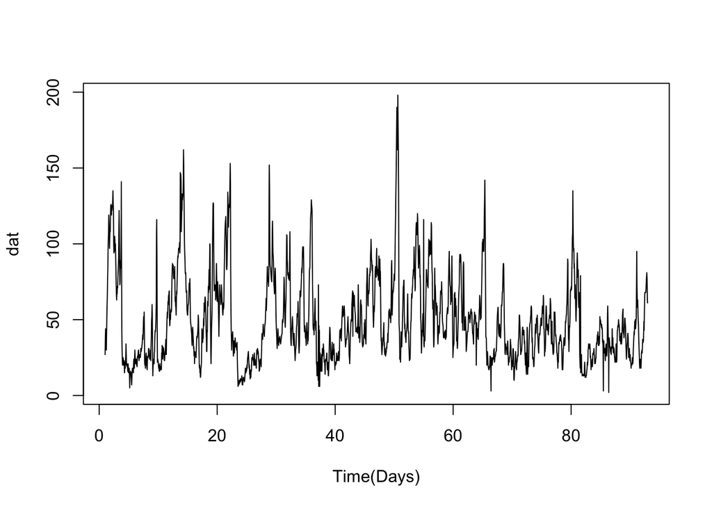

```r
#pick out the NA values
list_NA<-which(is.na(XuhuiPM_2015Spring$PM_Xuhui)>0)

#use the data of the corresponding time of the previous day to fill the missing data
XuhuiPM_2015Spring[list_NA,]$PM_Xuhui=XuhuiPM_2015Spring[list_NA-24,]$PM_Xuhui

#set the x-axis unit to be daily and plot the data
dat=ts(data=XuhuiPM_2015Spring$PM_Xuhui,frequency=24)
plot(dat,xlab="Time(Days)")
```

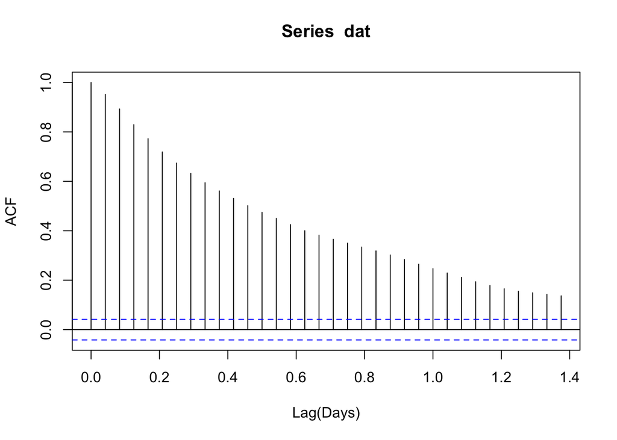

```r
acf(dat,xlab="Lag(Days)")
```

By looking at the ACF plot, we find that the PM2.5 concentration appears strong correlation with the previous data, suggesting that we should take difference of the data into account in our model.

# 3. Model Fitting and Selection

```r
aic_table <- function(data,P,Q){
  table <- matrix(NA,(P+1),(Q+1))
  for(p in 0:P) {
    for(q in 0:Q) {
       table[p+1,q+1] <- arima(data,order=c(p,1,q),include.mean=TRUE)$aic
    }
  }
  dimnames(table) <- list(paste("AR",0:P, sep=""),paste("MA",0:Q,sep=""))
  table
}
PM_aic_table <- aic_table(dat,4,5)
PM_aic_table
```

```
##          MA0      MA1      MA2      MA3      MA4      MA5
## AR0 15890.56 15863.41 15857.05 15850.06 15851.82 15833.95
## AR1 15860.73 15861.89 15849.38 15789.54 15790.15 15790.21
## AR2 15860.68 15851.97 15850.84 15786.53 15787.92 15788.92
## AR3 15847.35 15792.87 15785.94 15788.46 15790.15 15789.67
## AR4 15848.94 15789.09 15791.80 15789.58 15790.82 15785.30
```

```r
PM_arima312 <- arima(dat,order=c(3,1,2),include.mean=TRUE)
PM_arima312
```

```
##
## Call:
## arima(x = dat, order = c(3, 1, 2), include.mean = TRUE)
##
## Coefficients:
##          ar1     ar2      ar3      ma1      ma2
##       0.4015  0.6679  -0.1651  -0.3136  -0.6853
## s.e.  0.1186  0.1186   0.0221   0.1193   0.1189
##
## sigma^2 estimated as 74.28:  log likelihood = -7886.97,  aic = 15785.94
```

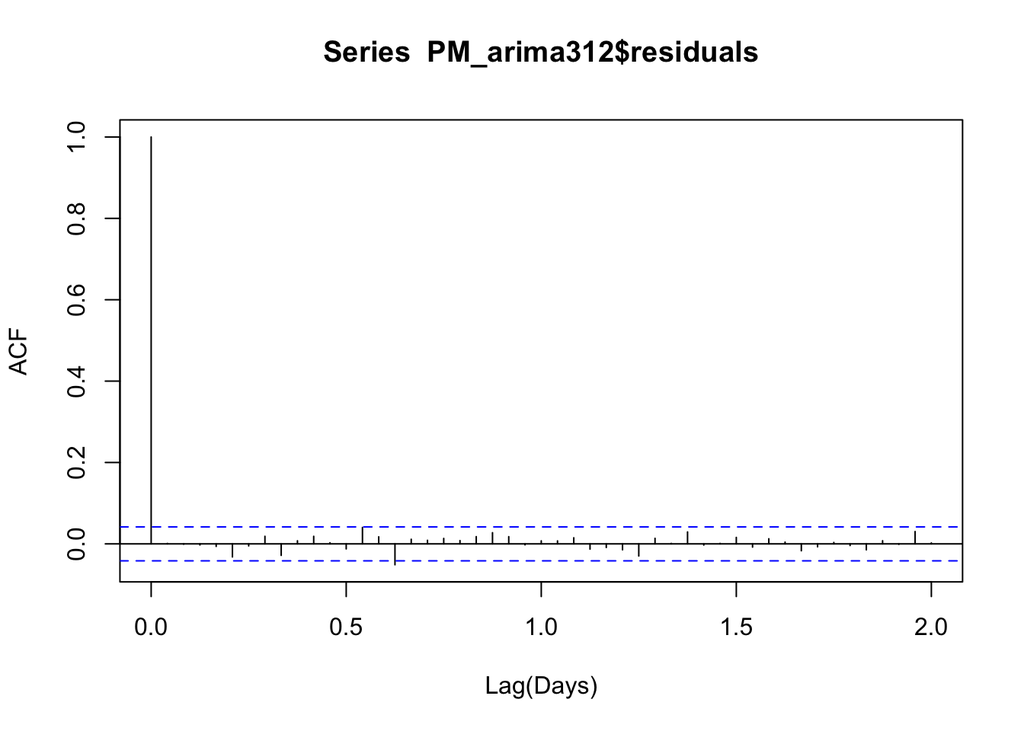

```r
acf(PM_arima312$residuals,lag.max=48,xlab="Lag(Days)")
```

There seems to be a seasonal pattern in the ACF plot of the residuals. Meanwhile, we suspect that fitting an ARIMA model for the original data may be inappropriate since it may not reflect the very sharp peaks we observed in the data plot. Next, we do a simulation study based on $ARIMA(3,1,2)$ to verify our idea.

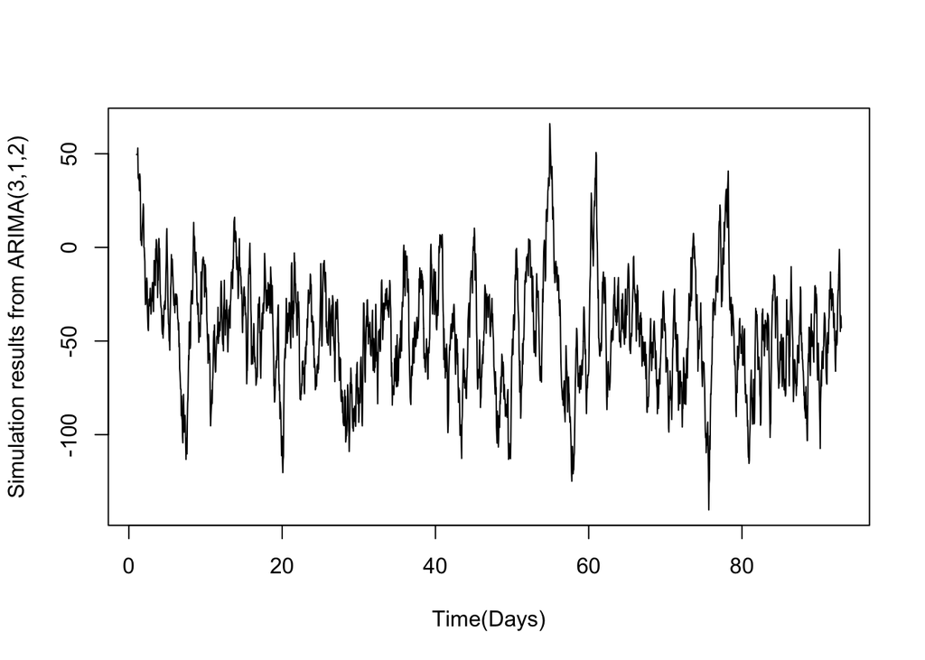

```r
Nt<-length(dat)
sim<-rep(0,Nt)
set.seed(1)
w<-rnorm(Nt,m=0,sd=sqrt(PM_arima312$sigma2))
for(nt in 5:Nt){
sim[nt]<-(1+PM_arima312$coef["ar1"])*sim[nt-1]-(PM_arima312$coef["ar1"]-PM_arima312$coef["ar2"])*sim[nt-2]-(PM_arima312$coef["ar2"]-PM_arima312$coef["ar3"])*sim[nt-3]-PM_arima312$coef["ar3"]*sim[nt-4]+PM_arima312$coef["ma1"]*w[nt-1]+PM_arima312$coef["ma2"]*w[nt-2]+w[nt]
}
sim<-sim+mean(dat)
sim_dat=ts(data=sim,frequency=24)
plot(sim_dat,xlab="Time(Days)",ylab="Simulation results from ARIMA(3,1,2)")
```

The simulation above shows that the ARIMA(3,1,2) model does not reflect the data quite well. There are many negative values, and we do not see sharp peaks. We may try to do a logarithm transformation of the data first and then fit an ARMIMA model.

```r
log_PM_aic_table <- aic_table(log(dat),3,3)
log_PM_aic_table
```

```
##            MA0       MA1       MA2       MA3
## AR0  -99.90622 -213.9941 -218.1488 -240.7275
## AR1 -225.59228 -238.3695 -244.0330 -249.8975
## AR2 -228.09653 -242.2778 -298.8925 -298.6245
## AR3 -246.35184 -247.6472 -298.4173 -295.8120
```

We pick the model ARIMA(2,1,2) for the transformed data based on least AIC criterion. The fitted parameters and ACF plot of the residuals are as follows.

```r
log_PM_arima212 <- arima(log(dat),order=c(2,1,2))
log_PM_arima212
```

```
##
## Call:
## arima(x = log(dat), order = c(2, 1, 2))
##
## Coefficients:
##          ar1     ar2      ma1      ma2
##       0.2342  0.6597  -0.4679  -0.5321
## s.e.  0.0592  0.0534   0.0694   0.0694
##
## sigma^2 estimated as 0.0508:  log likelihood = 154.45,  aic = -298.89
```

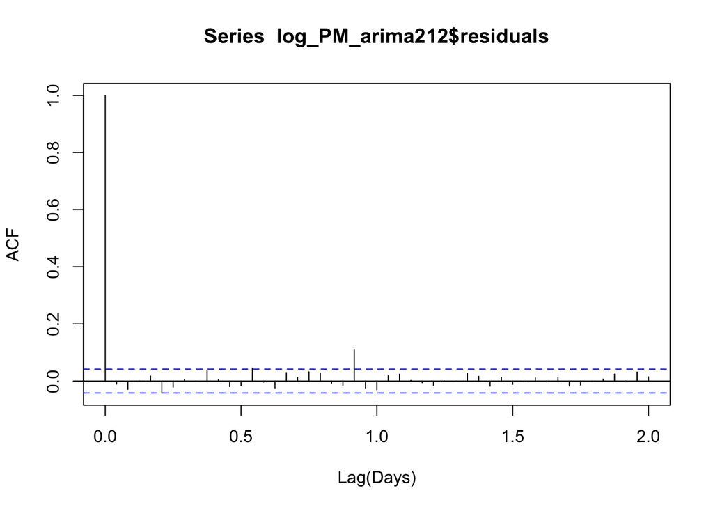

```r
acf(log_PM_arima212$residuals,lag.max=48,xlab="Lag(Days)")
```

```r
log_PM_sarima212101<-arima(x =log(dat) , order = c(2, 1, 2), seasonal = list(order = c(1, 0, 1), period = 24))
log_PM_sarima212101
```

```
##
## Call:
## arima(x = log(dat), order = c(2, 1, 2), seasonal = list(order = c(1, 0, 1),
##     period = 24))
##
## Coefficients:
##          ar1     ar2      ma1      ma2    sar1     sma1
##       0.2264  0.6688  -0.4595  -0.5405  0.1390  -0.1662
## s.e.  0.0567  0.0512   0.0670   0.0670  1.0501   1.0228
##
## sigma^2 estimated as 0.05076:  log likelihood = 155.29,  aic = -296.58
```

We do a profile likihood hypothesis test on the joint statistical significance of parameters $\Phi_1$ and $\Psi_1$.